# 1,2일차

```python
print("hello")
```

```
hello
```

```python
a = 10
```

```python
print(a)
```

```
10
```

```python
print("hello world")
```

```
hello world
```

# 안녕하세요

## 안녕하세요

### 안녕하세요

#### 안녕하세요

##### 안녕하세요

```python
print("hi")
```

```
hi
```

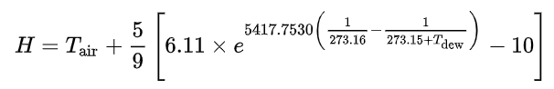

## Pandas

- Panel Data Analysis
- 파이썬에서 데이터 프레임(Data Frame) 다루는 도구
- pip install pandas
- 문서: https://pandas.pydata.org/docs/

## Data Frame

- 데이터가 틀에 맞춰서 저장된 형태
- 가로 x 세로 직사각형 모양으로 틀을 갖춰 저장
- 엑셀, 테이블, 데이터 프레임 등 분야마다 다르게 불림
- 한 row 안의 데이터는 Dictionary처럼 저장
- 한 column 안의 데이터는 list처럼 저장
- 한 데이터 프레임은 row들이 list처럼 저장

[figure not shown]

```python
import pandas as pd

all_list = []
all_list.append({'date':'2022-07-11', 'dayofweek':'mon'})
all_list.append({'date':'2022-07-12', 'dayofweek':'tue'})
all_list.append({'date':'2022-07-13', 'dayofweek':'wed'})
all_list
```

```
[{'date': '2022-07-11', 'dayofweek': 'mon'},
 {'date': '2022-07-12', 'dayofweek': 'tue'},
 {'date': '2022-07-13', 'dayofweek': 'wed'}]
```

```python
pd.DataFrame(all_list)
```

|  | date | dayofweek |
| --- | --- | --- |
| 0 | 2022-07-11 | mon |
| 1 | 2022-07-12 | tue |
| 2 | 2022-07-13 | wed |

```python
name = ['jo', 'kim', 'choi', 'lee', 'park']
age = [22, 31, 55, 17, 27]

DataSet = list(zip(name, age))
df = pd.DataFrame(data = DataSet, columns=['name', 'age'])
df
```

|  | name | age |
| --- | --- | --- |
| 0 | jo | 22 |
| 1 | kim | 31 |
| 2 | choi | 55 |
| 3 | lee | 17 |
| 4 | park | 27 |

```python
df.dtypes
```

```
name    object
age      int64
dtype: object
```

```python
df.index
```

```
RangeIndex(start=0, stop=5, step=1)
```

```python
df.columns
```

```
Index(['name', 'age'], dtype='object')
```

```python
df['name']
```

```
0      jo
1     kim
2    choi
3     lee
4    park
Name: name, dtype: object
```

```python
df
```

|  | name | age |
| --- | --- | --- |
| 0 | jo | 22 |
| 1 | kim | 31 |
| 2 | choi | 55 |
| 3 | lee | 17 |
| 4 | park | 27 |

```python
df[0:3]
```

|  | name | age |
| --- | --- | --- |
| 0 | jo | 22 |
| 1 | kim | 31 |
| 2 | choi | 55 |

```python
# 조건을 추가해 filtering
df[df['age'] > 30]
```

|  | name | age |
| --- | --- | --- |
| 1 | kim | 31 |
| 2 | choi | 55 |

```python
df['age'].mean()
```

```
30.4
```

## Numpy

- Numerical Python
- numpy의 자료구조는 pandas와 Matplotlib 라이브러리의 기본 데이터 타입으로 사용됨
- 배열 개념으로 변수를 사용하며 벡터, 행렬 등의 연산을 빠르게 수행하도록 지원
- 파이썬: list, dict
- 데이터 분석: numpy
- pip install numpy
- 문서: https://numpy.org/doc/stable/

```python
import numpy as np

arr = np.array([1, 3, 5, 7, 9])
arr
```

```
array([1, 3, 5, 7, 9])
```

```python
arr.shape
```

```
(5,)
```

```python
arr = np.array([[1, 3, 5, 7, 9], [2, 4, 6, 8, 10]])
arr
```

```
array([[ 1,  3,  5,  7,  9],
       [ 2,  4,  6,  8, 10]])
```

```python
arr.shape
```

```
(2, 5)
```

```python
arr.reshape(5, 2)
```

```
array([[ 1,  3],
       [ 5,  7],
       [ 9,  2],
       [ 4,  6],
       [ 8, 10]])
```

```python
arr.reshape(1, 10)
```

```
array([[ 1,  3,  5,  7,  9,  2,  4,  6,  8, 10]])
```

```python
np.zeros((2, 5))
```

```
array([[0., 0., 0., 0., 0.],
       [0., 0., 0., 0., 0.]])
```

## Matplotlib

- math plot library
- 1세대 그래프 그리는 도구로 데이터를 시각화해주는 라이브러리
- 문서: https://matplotlib.org/stable/index.html

```python
df
```

|  | name | age |
| --- | --- | --- |
| 0 | jo | 22 |
| 1 | kim | 31 |
| 2 | choi | 55 |
| 3 | lee | 17 |
| 4 | park | 27 |

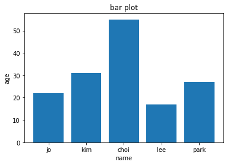

```python
import matplotlib.pyplot as plt

x = df['name']
y = df['age']

plt.bar(x, y)
plt.xlabel('name')
plt.ylabel('age')
plt.title('bar plot')
```

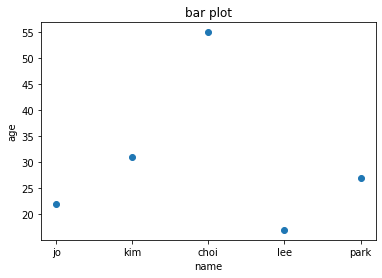

```python
plt.scatter(x, y)
plt.xlabel('name')
plt.ylabel('age')
plt.title('bar plot')
```

## pandas 자료구조

- series
- data frame

#### series

- 데이터가 순차적으로 나열된 1차원 배열 형태
- 키와 값이 '{k:v}' 형태로 짝을 이루는 파이썬 Dict와 비슷한 구조를 갖음
- k --> index
- v --> value

```python
import pandas as pd

dic = {'a': 1, 'b':2, 'c':3}
sr = pd.Series(dic)

type(sr)
```

```
pandas.core.series.Series
```

```python
# list -> series
ls = ['jo', 'kim', 'lee', 'park', 'choi']
sr = pd.Series(ls)
sr
```

```
0      jo
1     kim
2     lee
3    park
4    choi
dtype: object
```

```python
sr.values
```

```
array(['jo', 'kim', 'lee', 'park', 'choi'], dtype=object)
```

```python
sr.index
```

```
RangeIndex(start=0, stop=5, step=1)
```

#### Data frame

```python
dic = {'c0':[1,2,3], 'c1':[4,5,6], 'c2':[7,8,9], 'c3':[10, 11, 12], 'c4':[13, 14, 15]}
df = pd.DataFrame(dic)
df
```

|  | c0 | c1 | c2 | c3 | c4 |
| --- | --- | --- | --- | --- | --- |
| 0 | 1 | 4 | 7 | 10 | 13 |
| 1 | 2 | 5 | 8 | 11 | 14 |
| 2 | 3 | 6 | 9 | 12 | 15 |

```python
df = pd.DataFrame([[20224943, '컴퓨터공학', 1], [20201234, '전자공학', 2]],
            columns=['학번', '전공', '학년'],
            index=['jo', 'kim'])
df
```

|  | 학번 | 전공 | 학년 |
| --- | --- | --- | --- |
| jo | 20224943 | 컴퓨터공학 | 1 |
| kim | 20201234 | 전자공학 | 2 |

```python
df.columns = ['number', 'major', 'grade']
df.index = ['lee', 'park']
df
```

|  | number | major | grade |
| --- | --- | --- | --- |
| lee | 20224943 | 컴퓨터공학 | 1 |
| park | 20201234 | 전자공학 | 2 |

```python
df.rename(index={'lee':'jo', 'park':'kim'}, inplace=True)
df.rename(columns={'number':'stuNumber'}, inplace=True)
df
```

|  | stuNumber | major | grade |
| --- | --- | --- | --- |
| jo | 20224943 | 컴퓨터공학 | 1 |
| kim | 20201234 | 전자공학 | 2 |

```python
dic = {'국어':[95, 88, 72], '영어':[66, 80, 94], '수학':[100, 77, 89]}
df = pd.DataFrame(dic, index=['jo', 'kim', 'lee'])
df
```

|  | 국어 | 영어 | 수학 |
| --- | --- | --- | --- |
| jo | 95 | 66 | 100 |
| kim | 88 | 80 | 77 |
| lee | 72 | 94 | 89 |

```python
df2 = df[:]
df2.drop(index='lee', inplace=True)
df2
```

|  | 국어 | 영어 | 수학 |
| --- | --- | --- | --- |
| jo | 95 | 66 | 100 |
| kim | 88 | 80 | 77 |

```python
df3 = df[:]
#df3.drop('국어', axis=1, inplace=True)
df3 = df3.drop('국어', axis=1)
df3
```

|  | 영어 | 수학 |
| --- | --- | --- |
| jo | 66 | 100 |
| kim | 80 | 77 |
| lee | 94 | 89 |

```python
df
```

|  | 국어 | 영어 | 수학 |
| --- | --- | --- | --- |
| jo | 95 | 66 | 100 |
| kim | 88 | 80 | 77 |
| lee | 72 | 94 | 89 |

```python
# row 선택

df.loc['jo']
```

```
국어     95
영어     66
수학    100
Name: jo, dtype: int64
```

```python
df.iloc[0]
```

```
국어     95
영어     66
수학    100
Name: jo, dtype: int64
```

```python
df.loc[['jo', 'kim']]
```

|  | 국어 | 영어 | 수학 |
| --- | --- | --- | --- |
| jo | 95 | 66 | 100 |
| kim | 88 | 80 | 77 |

```python
df.iloc[[0, 1]]
```

|  | 국어 | 영어 | 수학 |
| --- | --- | --- | --- |
| jo | 95 | 66 | 100 |
| kim | 88 | 80 | 77 |

```python
df.loc['jo':'kim']
```

|  | 국어 | 영어 | 수학 |
| --- | --- | --- | --- |
| jo | 95 | 66 | 100 |
| kim | 88 | 80 | 77 |

```python
df.iloc[::-1]
```

|  | 국어 | 영어 | 수학 |
| --- | --- | --- | --- |
| lee | 72 | 94 | 89 |
| kim | 88 | 80 | 77 |
| jo | 95 | 66 | 100 |

```python
# column 선택

df[['국어']]
# df.국어
```

|  | 국어 |
| --- | --- |
| jo | 95 |
| kim | 88 |
| lee | 72 |

```python
df[['국어', '영어']]
```

|  | 국어 | 영어 |
| --- | --- | --- |
| jo | 95 | 66 |
| kim | 88 | 80 |
| lee | 72 | 94 |

```python
df
```

|  | 국어 | 영어 | 수학 |
| --- | --- | --- | --- |
| jo | 95 | 66 | 100 |
| kim | 88 | 80 | 77 |
| lee | 72 | 94 | 89 |

```python
# 원소 선택
df.loc['kim', ['국어', '영어']]
```

```
국어    88
영어    80
Name: kim, dtype: int64
```

```python
df.loc[:, ['국어', '수학']]
```

|  | 국어 | 수학 |
| --- | --- | --- |
| jo | 95 | 100 |
| kim | 88 | 77 |
| lee | 72 | 89 |

```python
df
```

|  | 국어 | 영어 | 수학 |
| --- | --- | --- | --- |
| jo | 95 | 66 | 100 |
| kim | 88 | 80 | 77 |
| lee | 72 | 94 | 89 |

```python
# 추가
df['코딩'] = 70
df
```

|  | 국어 | 영어 | 수학 | 코딩 |
| --- | --- | --- | --- | --- |
| jo | 95 | 66 | 100 | 70 |
| kim | 88 | 80 | 77 | 70 |
| lee | 72 | 94 | 89 | 70 |

```python
df.loc['park'] = [98, 95, 89, 92]
df
```

|  | 국어 | 영어 | 수학 | 코딩 |
| --- | --- | --- | --- | --- |
| jo | 95 | 66 | 100 | 70 |
| kim | 88 | 80 | 77 | 70 |
| lee | 72 | 94 | 89 | 70 |
| park | 98 | 95 | 89 | 92 |

```python
#df.loc['jo', '코딩']
df.loc['jo']['코딩'] = 80
df
```

|  | 국어 | 영어 | 수학 | 코딩 |
| --- | --- | --- | --- | --- |
| jo | 95 | 66 | 100 | 80 |
| kim | 88 | 80 | 77 | 70 |
| lee | 72 | 94 | 89 | 70 |
| park | 98 | 95 | 89 | 92 |

```python
#df.loc['kim'][['영어', '수학']]
df.loc['kim', ['영어', '수학']] = 95, 70
df
```

|  | 국어 | 영어 | 수학 | 코딩 |
| --- | --- | --- | --- | --- |
| jo | 95 | 66 | 100 | 80 |
| kim | 88 | 95 | 70 | 70 |
| lee | 72 | 94 | 89 | 70 |
| park | 98 | 95 | 89 | 92 |

```python
#df.transpose()
df = df.T
df
```

|  | jo | kim | lee | park |
| --- | --- | --- | --- | --- |
| 국어 | 95 | 88 | 72 | 98 |
| 영어 | 66 | 95 | 94 | 95 |
| 수학 | 100 | 70 | 89 | 89 |
| 코딩 | 80 | 70 | 70 | 92 |

```python
# index

dic = {'이름': ['jo', 'kim', 'lee', 'park'],
      '국어': [95, 88, 72, 98],
      '영어': [66, 95, 94, 95],
      '수학': [100, 70, 89, 89],
      '코딩': [80, 70, 70, 92]}
df = pd.DataFrame(dic)
df
```

|  | 이름 | 국어 | 영어 | 수학 | 코딩 |
| --- | --- | --- | --- | --- | --- |
| 0 | jo | 95 | 66 | 100 | 80 |
| 1 | kim | 88 | 95 | 70 | 70 |
| 2 | lee | 72 | 94 | 89 | 70 |
| 3 | park | 98 | 95 | 89 | 92 |

```python
df2 = df.set_index('이름')
df2
```

| 이름 | 국어 | 영어 | 수학 | 코딩 |
| --- | --- | --- | --- | --- |
| jo | 95 | 66 | 100 | 80 |
| kim | 88 | 95 | 70 | 70 |
| lee | 72 | 94 | 89 | 70 |
| park | 98 | 95 | 89 | 92 |

```python
df2.set_index('국어')
```

| 국어 | 영어 | 수학 | 코딩 |
| --- | --- | --- | --- |
| 95 | 66 | 100 | 80 |
| 88 | 95 | 70 | 70 |
| 72 | 94 | 89 | 70 |
| 98 | 95 | 89 | 92 |

```python
df2.set_index(['수학', '코딩'])
```

| 수학 | 코딩 | 국어 | 영어 |
| --- | --- | --- | --- |
| 100 | 80 | 95 | 66 |
| 70 | 70 | 88 | 95 |
| 89 | 70 | 72 | 94 |
|  | 92 | 98 | 95 |